# Part II - Characteristics of bike trips

## by Abdelmadjid Chergui

## Investigation Overview

> In this investigation, I wanted to look at the characteristics of bike trips that could be used to gain insights about duration in terms of time of day, day of the week, or month of the year and its variation by user type and gender.

## Dataset Overview

> The data set includes information about individual rides made in a bike-sharing system covering the greater San Francisco Bay Area.

## Distribution of trips durations

when plotted in log-scale the duration variable looks uni-model with a peak between 9 and 15 minutes after removing outliers.

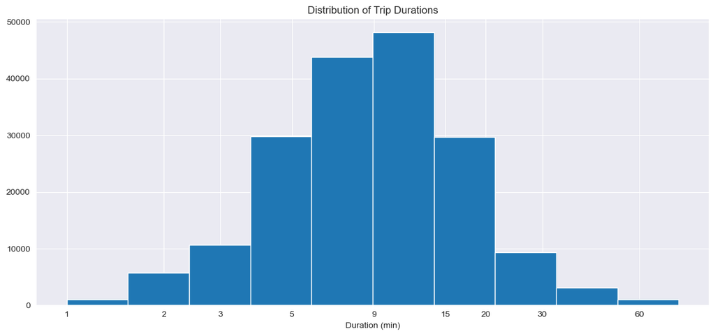

## Distribution of members by gender

most customers are males by a large number.

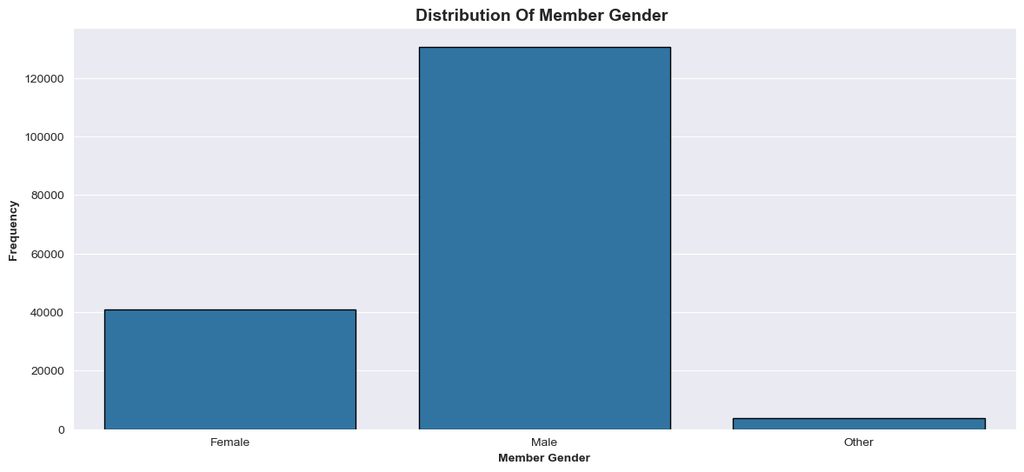

## Distribution of user types

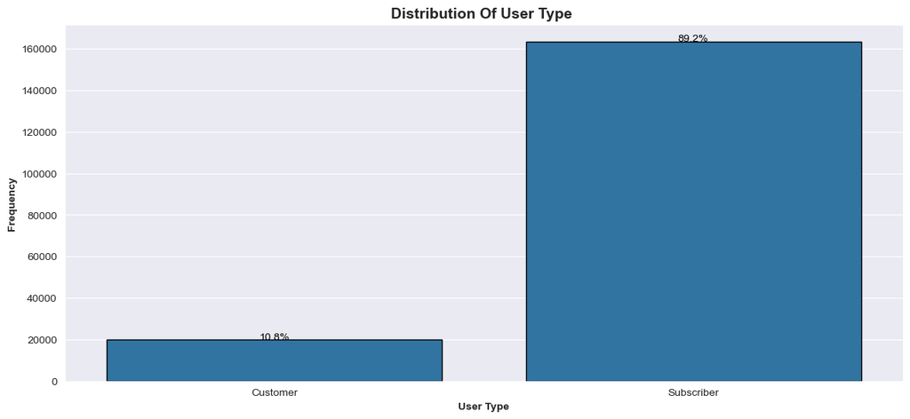

## Most frequent station

The San Fransisco Caltrain Station 2 is the most frequent station if we combine the counts from start and end station of each trip.

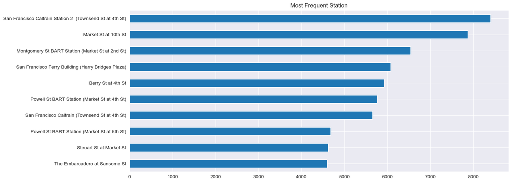

## Average duration by days of week

the data show an increase in average duration of trips in the weekends.

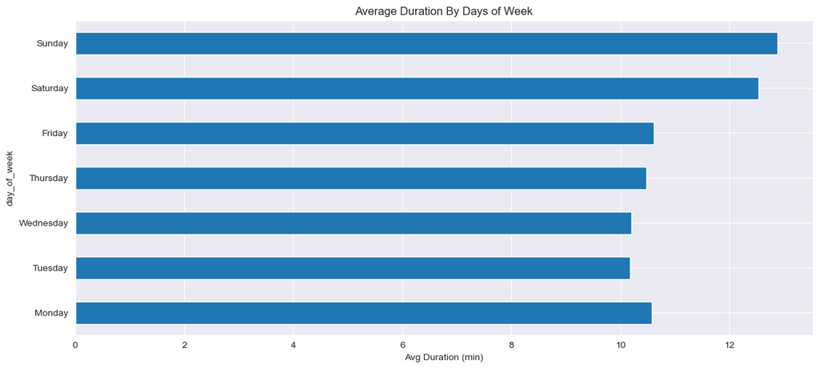

## Average duration across days of week and user type

we see here a very steep increase in average duration for `Customer` in weekends in comparison to the increase for `Subscriber` members.

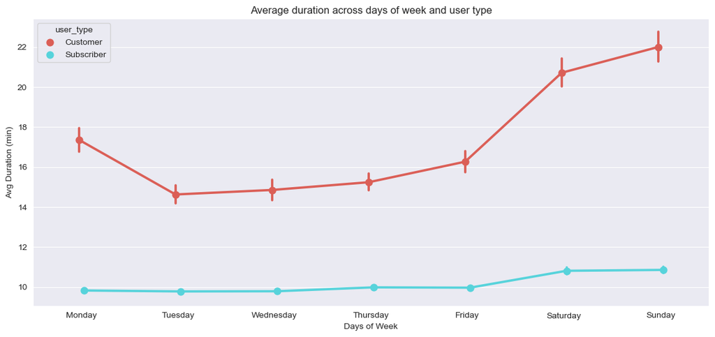